# Add HCRIS data

## Setup

Load necessary libraries:

```r
library(tidyverse)
library(tidyr)
library(dplyr)
library(janitor)
library(ggplot2)
library(hrbrthemes)
library(GGally)
library(tabulator)
library(readxl)
library(broom)
library(plm)
library(openxlsx)
library(gt)
library(readr)
```

Load in manually cleaned data set:

```r
Manual_matched <- read_excel("Data_manual_cleaning.xlsx",
    sheet = "Deleted non matched", skip = 2)
View(Manual_matched)
```

Load in NASHP ownership data:

```r
NASHP <- read_excel("NASHP HCT Data 2024 July.xlsx",
    sheet = "Downloadable")
View(NASHP)
```

Filter NASHP data to focus on New York.

```r
cleaned_NASHP <- NASHP %>% filter(State == "NY")
```

R sometimes throws errors due to the complexity of the NASHP data set. In order to prevent future loading and crashing problems I write the filtered data set so I have a backup for potential use in future. Name new csv file cleanNASHP in the data folder under Thesis GU.

```r
write.csv(cleaned_NASHP, "C:/Users/Mitchell/Documents/Thesis GU/Data/cleanNASHP.csv")
print(cleaned_NASHP)
```

```
# A tibble: 2,065 × 107
   `CCN#` `Facility Type`       Year Fiscal Year Beginnin…¹ `Fiscal Year Ending`
   <chr>  <chr>                <dbl> <dttm>                 <dttm>
 1 330002 Short Term (General…  2011 2011-01-01 00:00:00    2011-12-31 00:00:00
 2 330002 Short Term (General…  2012 2012-01-01 00:00:00    2012-04-08 00:00:00
 3 330003 Short Term (General…  2011 2011-01-01 00:00:00    2011-12-31 00:00:00
 4 330003 Short Term (General…  2012 2012-01-01 00:00:00    2012-12-31 00:00:00
 5 330003 Short Term (General…  2013 2013-01-01 00:00:00    2013-06-30 00:00:00
 6 330003 Short Term (General…  2014 2013-07-01 00:00:00    2014-06-30 00:00:00
 7 330003 Short Term (General…  2015 2014-07-01 00:00:00    2015-06-30 00:00:00
 8 330003 Short Term (General…  2016 2015-07-01 00:00:00    2016-06-30 00:00:00
 9 330003 Short Term (General…  2017 2016-07-01 00:00:00    2017-06-30 00:00:00
10 330003 Short Term (General…  2018 2017-07-01 00:00:00    2018-06-30 00:00:00
# ℹ 2,055 more rows
# ℹ abbreviated name: ¹`Fiscal Year Beginning`
# ℹ 102 more variables: `Hospital Name` <chr>,
#   `Hospital Abbreviated Name` <chr>, Address <chr>, `Zip Code` <chr>,
#   City <chr>, State <chr>, `Health System ID` <chr>, `Health System` <chr>,
#   `Hospital Ownership Type` <chr>, Independent <dbl>, `Bed Size` <dbl>,
#   `Inpatient Occupancy` <dbl>, `Net Patient Revenue` <chr>, …
```

Exploring cleaned NASHP data.

```r
View(cleaned_NASHP %>% count(`Hospital Ownership Type`))

for_viz <-(cleaned_NASHP %>% group_by(Year) %>% count(`Hospital Ownership Type`)) %>% ungroup()
```

## Table

```r
gt_viz_tbl <- for_viz %>%
    mutate(`Number of Hospitals` = n) %>% select(-n) %>%
  gt() %>%
  tab_header(
    title = "Number of Hospitals by Ownership Type from 2011 to 2022"
  ) %>%
  tab_spanner(label = "Ownership Information",
    columns = c(`Hospital Ownership Type`, `Number of Hospitals`)) %>%
  tab_spanner(label = "Time",
              columns = Year)

gt_viz_tbl %>%
  gtsave(filename = "Hospitals2011to2022tbl2.htm")
```

## Grouped line chart.

```r
numberhospitalsgraph <- for_viz %>%
  ggplot(mapping = aes(x = Year, group = `Hospital Ownership Type`, y = n, color = `Hospital Ownership Type`)) +
  geom_line() +
  scale_y_continuous(breaks = seq(0, 175, by = 25)) +
  scale_x_continuous(breaks = c(2012, 2014, 2016, 2018, 2020, 2022)) +
  labs(title = "Number of Hospitals in New York State from 2011 to 2022",
       subtitle = "There are a small number of For-Profit Hospitals in New York State") +
  xlab("Year") +
  ylab("Number of Hospitals") +
  theme_minimal()

ggsave("numberhospitalsgraph.png")
```

Merge manually cleaned set to cleaned NASHP data set by CCN.

```r
ccn_cleaned_NASHP <- cleaned_NASHP %>% rename( ccn = `CCN#`) %>% transform(ccn= as.numeric(ccn))

Combined <- full_join(x = Manual_matched,
          y = ccn_cleaned_NASHP,
          by = "ccn",
          copy = FALSE,
          keep = NULL) %>% clean_names()
```

Load SPARCS data set

```r
ppc_rates <- read_csv("All_Payer_Inpatient_Major_Potentially_Preventable_Complication__PPC__Rates_by_Hospital__SPARCS___Beginning_2013_20241001.csv")
View(ppc_rates)
```

Merging SPARCS data set to NASHP and Manual matched. Use right join to maintain the additional years of observations not present in ppc_rates data.

```r
ppc_rates_janitor <- ppc_rates %>% clean_names() %>% rename( year = discharge_year)

SPARCS_combined <- right_join(x = ppc_rates_janitor,
                             y = Combined,
                             by = c("facility_id", "year"),
                             copy = FALSE,
                             keep = NULL)
```

Add in AHRQ cross sectional data sets. Note documentation shows that coding is not standardized between years. For instance a 2 in hospital ownership in 2022 is a public or governmental hospital while in 2020 a 2 means church-operated. Only 2021 includes 4 equals federal.

```r
AHRQ2022 <- read_excel("AHRQ datasets/chsp-hospital-linkage-2022-rev.xlsx")
View(AHRQ2022)

Cleaned2022 <- AHRQ2022 %>% filter(hospital_state == "NY")

Cleanedmore2022 <- Cleaned2022 %>% mutate(year = case_when(
  hospital_state == "NY" ~ 2022
)) %>% mutate(hos_ownership = case_when(
  hos_ownership == 1 ~ "Non-Profit",
  hos_ownership == 2 ~ "Governmental",
  hos_ownership == 3 ~ "Church-Operated",
  hos_ownership == 5 ~ "For-Profit"
  )) %>% transform(ccn = as.double(ccn))


#^recode var hos_ownership so the number are characters.

AHRQ2021 <- read_excel("AHRQ datasets/chsp-hospital-linkage-2021-rev.xlsx")
View(AHRQ2021)

Cleaned2021 <- AHRQ2021 %>% filter(hospital_state == "NY") %>% mutate(year = case_when(
  hospital_state == "NY" ~ 2021
)) %>% mutate(hos_ownership = case_when(
  hos_ownership == 1 ~ "Non-Profit",
  hos_ownership == 2 ~ "Church-Operated",
  hos_ownership == 3 ~ "Governmental",
  hos_ownership == 4 ~ "Federal",
  hos_ownership == 5 ~ "For-Profit"
  )) %>% transform(ccn = as.double(ccn))

#^recode var hos_ownership so the number are characters.

AHRQ2020 <- read_excel("AHRQ datasets/chsp-hospital-linkage-2020-rev.xlsx")
View(AHRQ2020)

Cleaned2020 <- AHRQ2020 %>% filter(hospital_state == "NY") %>% mutate(year = case_when(
  hospital_state == "NY" ~ 2020
)) %>% mutate(hos_ownership = case_when(
  hos_ownership == 1 ~ "Non-Profit",
  hos_ownership == 2 ~ "Church-Operated",
  hos_ownership == 3 ~ "Governmental",
  hos_ownership == 5 ~ "For-Profit"
  )) %>% transform(ccn = as.double(ccn))
```

Combine AHRQ cross-sectional data with already combined data sets (NASHP/SPARCS/Manually Cleaned).

```r
Fully_combined <- left_join(
  x = SPARCS_combined,
  y = Cleanedmore2022,
  by = c("ccn", "year"),
  copy = FALSE,
  keep = NULL)

Fully_combined <- left_join(
  x = Fully_combined,
  y = Cleaned2021,
  by = c("ccn", "year"),
  copy = FALSE,
  keep = NULL)

Fully_combined <- left_join(
  x = Fully_combined,
  y = Cleaned2020,
  by = c("ccn", "year"),
  copy = FALSE,
  keep = NULL)
```

Write fully combined data set to excel as a backup and for my advisor.

```r
write.xlsx(Fully_combined, 'Fully_combined_dataset_init.xlsx')
```

Renamed this to init after it originally ended in _dataset.

## Add Cross Sectional County Data

```r
# 2011
year_2011 <- read_excel("County_data/2011 County Health Ranking New York Data - v4.xlsx",
    sheet = "Additional Measure Data",
    skip = 1) %>%
  drop_na(County)

year_2011_v2 <- read_excel("County_data/2011 County Health Ranking New York Data - v4.xlsx",
    sheet = "Ranked Measure Data", skip = 1) %>%
  drop_na(County)

combined_2011 <- full_join(year_2011,
                           year_2011_v2,
                           by = "County",
                           keep = FALSE)

combined_2011 <- combined_2011 %>%
  mutate(year = 2011) %>%
  clean_names() %>%
  select(county,
         year,
         rural,
         female,
         percent_children_in_poverty, percent_unemployed,
         percent_smokers,
         percent_obese,
         percent_excessive_drinking,
         percent_uninsured,
         household_income,
         mentally_unhealthy_days,
         population_4,
         x65_and_over,
         african_american,
         hispanic,
         percent_not_proficient_in_english)

# 2012
year_2012 <- read_excel("County_data/2012 County Health Ranking New York Data - v4.xlsx",
    sheet = "Ranked Measure Data", skip = 1) %>%
  drop_na(County)

year_2012_v2 <- read_excel("County_data/2012 County Health Ranking New York Data - v4.xlsx",
    sheet = "Additional Measure Data", skip = 1) %>%
  drop_na(County)

combined_2012 <- full_join(year_2012,
                           year_2012_v2,
                           by = "County",
                           keep = FALSE)

combined_2012 <- combined_2012 %>%
  mutate(year = 2012) %>%
  clean_names() %>%
  select(county,
         year,
         rural,
         female,
         percent_children_in_poverty, percent_unemployed,
         percent_smokers,
         percent_obese,
         percent_excessive_drinking,
         percent_uninsured_x,
         household_income,
         mentally_unhealthy_days,
         population_4,
         x65_and_over,
         african_american,
         hispanic,
         percent_not_proficient_in_english) %>%
  mutate(percent_uninsured = percent_uninsured_x) %>% select(-percent_uninsured_x)

# combine 2011 and 2012
rm(year_2011,
   year_2011_v2,
   year_2012,
   year_2012_v2)

Combined2011and2012 <- full_join(combined_2011,
                            combined_2012,
                            by = c("county",
         "year",
         "rural",
         "female",
         "percent_children_in_poverty", "percent_unemployed",
         "percent_smokers",
         "percent_obese",
         "percent_excessive_drinking",
         "percent_uninsured",
         "household_income",
         "mentally_unhealthy_days",
         "population_4",
         "x65_and_over",
         "african_american",
         "hispanic",
         "percent_not_proficient_in_english")) %>%
  mutate(population_y = population_4)

# 2013
year_2013 <- read_excel("County_data/2013 County Health Ranking New York Data - v1_0.xlsx",
    sheet = "Ranked Measure Data", skip = 1) %>%
  drop_na(County)

year_2013_v2 <- read_excel("County_data/2013 County Health Ranking New York Data - v1_0.xlsx",
    sheet = "Additional Measure Data", skip = 1) %>%
  drop_na(County)

combined_2013 <- full_join(year_2013,
                           year_2013_v2,
                           by = "County")

combined_2013 <- combined_2013 %>%
  mutate(year = 2013) %>%
  clean_names() %>%
  select(county,
         year,
         rural,
         female,
         percent_children_in_poverty, percent_unemployed,
         percent_smokers,
         percent_obese,
         percent_excessive_drinking,
         percent_uninsured,
         household_income,
         mentally_unhealthy_days,
         population_y,
         x65_and_over,
         african_american,
         hispanic,
         percent_not_proficient_in_english)

#View(combined_2013 %>% select(county, contains("population")))

# 2014
year_2014 <- read_excel("County_data/2014 County Health Rankings New York Data - v6.xlsx",
    sheet = "Ranked Measure Data", skip = 1) %>%
  drop_na(County)

year_2014_v2 <- read_excel("County_data/2014 County Health Rankings New York Data - v6.xlsx",
    sheet = "Additional Measure Data", skip = 1) %>%
  drop_na(County)

combined_2014 <- left_join(year_2014,
                           year_2014_v2,
                           by = "County")

combined_2014 <- combined_2014 %>%
  mutate(year = 2014) %>%
  clean_names() %>%
  select(county,
         year,
         rural,
         female,
         percent_children_in_poverty, percent_unemployed,
         percent_smokers,
         percent_obese,
         percent_excessive_drinking,
         percent_uninsured,
         household_income,
         mentally_unhealthy_days,
         population_y,
         x65_and_over,
         african_american,
         hispanic,
         percent_not_proficient_in_english)

#combine 2013 and 2014
rm(year_2013,
   year_2013_v2,
   year_2014,
   year_2014_v2)


Combined2013and2014 <- full_join(combined_2013,
                            combined_2014,
                            by = c("county",
         "year",
         "rural",
         "female",
         "percent_children_in_poverty", "percent_unemployed",
         "percent_smokers",
         "percent_obese",
         "percent_excessive_drinking",
         "percent_uninsured",
         "household_income",
         "mentally_unhealthy_days",
         "population_y",
         "x65_and_over",
         "african_american",
         "hispanic",
         "percent_not_proficient_in_english"))

# Combine 2011 - 2014
rm(combined_2011,
   combined_2012,
   combined_2013,
   combined_2014)

Combined2011through2014 <- full_join(Combined2011and2012,
                            Combined2013and2014,
                            by = c("county",
         "year",
         "rural",
         "female",
         "percent_children_in_poverty", "percent_unemployed",
         "percent_smokers",
         "percent_obese",
         "percent_excessive_drinking",
         "percent_uninsured",
         "household_income",
         "mentally_unhealthy_days",
         "population_y",
         "x65_and_over",
         "african_american",
         "hispanic",
         "percent_not_proficient_in_english"))
```

```r
rm(Combined2011and2012,
   Combined2013and2014)

# 2015

year_2015 <- read_excel("County_data/2015 County Health Rankings New York Data - v3.xlsx",
    sheet = "Ranked Measure Data", skip = 1) %>%
  drop_na(County)

year_2015_v2 <- read_excel("County_data/2015 County Health Rankings New York Data - v3.xlsx",
    sheet = "Additional Measure Data", skip = 1) %>%
  drop_na(County)

combined_2015 <- left_join(year_2015,
                           year_2015_v2,
                           by = "County") %>%
  mutate(year = 2015) %>%
  clean_names() %>%
  select(county,
         year,
         percent_rural,
         percent_female,
         percent_children_in_poverty, percent_unemployed,
         percent_smokers,
         percent_obese,
         percent_excessive_drinking,
         percent_uninsured,
         household_income,
         mentally_unhealthy_days,
         population_y,
         percent_65_and_over,
         percent_african_american,
         percent_hispanic,
         percent_not_proficient_in_english)

# 2016

year_2016 <- read_excel("County_data/2016 County Health Rankings New York Data - v3.xlsx",
    sheet = "Ranked Measure Data", skip = 1) %>%
  drop_na(County)

year_2016_v2 <- read_excel("County_data/2016 County Health Rankings New York Data - v3.xlsx",
    sheet = "Additional Measure Data", skip = 1) %>%
  drop_na(County)

combined_2016 <- left_join(year_2016,
                           year_2016_v2,
                           by = "County") %>%
  mutate(year = 2016) %>%
  clean_names() %>%
  select(county,
         year,
         percent_rural,
         percent_female,
         percent_children_in_poverty, percent_unemployed,
         percent_smokers,
         percent_obese,
         percent_excessive_drinking,
         percent_uninsured,
         household_income,
         mentally_unhealthy_days,
         population_y,
         percent_65_and_over,
         percent_african_american,
         percent_hispanic,
         percent_not_proficient_in_english)

# combine 2015 and 2016
rm(year_2015,
   year_2015_v2,
   year_2016,
   year_2016_v2)

combined2015and2016 <- full_join(combined_2015,
                                  combined_2016,
                                  by = c("county",
         "year",
         "percent_rural",
         "percent_female",
         "percent_children_in_poverty", "percent_unemployed",
         "percent_smokers",
         "percent_obese",
         "percent_excessive_drinking",
         "percent_uninsured",
         "household_income",
         "mentally_unhealthy_days",
         "population_y",
         "percent_65_and_over",
         "percent_african_american",
         "percent_hispanic",
         "percent_not_proficient_in_english"))


# 2017

year_2017 <- read_excel("County_data/2017 County Health Rankings New York Data - v2.xlsx",
    sheet = "Ranked Measure Data", skip = 1) %>%
  drop_na(County)

year_2017_v2 <- read_excel("County_data/2017 County Health Rankings New York Data - v2.xlsx",
    sheet = "Additional Measure Data", skip = 1) %>%
  drop_na(County)

combined_2017 <- left_join(year_2017,
                           year_2017_v2,
                           by = "County") %>%
  mutate(year = 2017) %>%
  clean_names() %>%
  select(county,
         year,
         percent_rural,
         percent_female,
         percent_children_in_poverty, percent_unemployed,
         percent_smokers,
         percent_obese,
         percent_excessive_drinking,
         percent_uninsured,
         household_income,
         mentally_unhealthy_days,
         population_y,
         percent_65_and_over,
         percent_african_american,
         percent_hispanic,
         percent_not_proficient_in_english)

# 2018
year_2018 <- read_excel("County_data/2018 County Health Rankings New York Data - v3.xlsx",
    sheet = "Ranked Measure Data", skip = 1) %>%
  drop_na(County)

year_2018_v2 <- read_excel("County_data/2018 County Health Rankings New York Data - v3.xlsx",
    sheet = "Additional Measure Data", skip = 1) %>%
  drop_na(County)

combined_2018 <- left_join(year_2018,
                           year_2018_v2,
                           by = "County") %>%
  mutate(year = 2018) %>%
  clean_names() %>%
  select(county,
         year,
         percent_rural,
         percent_female,
         percent_children_in_poverty, percent_unemployed,
         percent_smokers,
         percent_obese,
         percent_excessive_drinking,
         percent_uninsured,
         household_income,
         mentally_unhealthy_days,
         population_y,
         percent_65_and_over,
         percent_african_american,
         percent_hispanic,
         percent_not_proficient_in_english)

# Combine 2017 and 2018
rm(year_2017,
   year_2017_v2,
   year_2018,
   year_2018_v2)

combined2017and2018 <- full_join(combined_2017,
                                  combined_2018,
                                  by = c("county",
         "year",
         "percent_rural",
         "percent_female",
         "percent_children_in_poverty", "percent_unemployed",
         "percent_smokers",
         "percent_obese",
         "percent_excessive_drinking",
         "percent_uninsured",
         "household_income",
         "mentally_unhealthy_days",
         "population_y",
         "percent_65_and_over",
         "percent_african_american",
         "percent_hispanic",
         "percent_not_proficient_in_english"))

# combine 2015-2018
rm(combined_2015,
   combined_2016,
   combined_2017,
   combined_2018)

combined2015thru2018 <- full_join(combined2015and2016,
                                  combined2017and2018,
                                  by = c("county",
         "year",
         "percent_rural",
         "percent_female",
         "percent_children_in_poverty", "percent_unemployed",
         "percent_smokers",
         "percent_obese",
         "percent_excessive_drinking",
         "percent_uninsured",
         "household_income",
         "mentally_unhealthy_days",
         "population_y",
         "percent_65_and_over",
         "percent_african_american",
         "percent_hispanic",
         "percent_not_proficient_in_english"))
```

```r
rm(combined2015and2016,
   combined2017and2018)

# 2019

year_2019 <- read_excel("County_data/2019 County Health Rankings New York Data - v1_0.xlsx",
    sheet = "Ranked Measure Data", skip = 1) %>%
  drop_na(County)

year_2019_v2 <- read_excel("County_data/2019 County Health Rankings New York Data - v1_0.xlsx",
    sheet = "Additional Measure Data", skip = 1) %>%
  drop_na(County)

combined_2019 <- left_join(year_2019,
                           year_2019_v2,
                           by = "County") %>%
  mutate(year = 2019) %>%
  clean_names() %>%
  select(county,
         year,
         percent_rural,
         percent_female,
         percent_children_in_poverty,
         percent_unemployed,
         percent_smokers,
         percent_obese,
         percent_excessive_drinking,
         percent_uninsured,
         household_income,
         mentally_unhealthy_days,
         population_y,
         percent_65_and_over,
         percent_african_american,
         percent_hispanic,
         percent_not_proficient_in_english)

# 2020

year_2020 <- read_excel("County_data/2020 County Health Rankings New York Data - v1_0.xlsx",
    sheet = "Ranked Measure Data", skip = 1) %>%
  drop_na(County)

year_2020_v2 <- read_excel("County_data/2020 County Health Rankings New York Data - v1_0.xlsx",
    sheet = "Additional Measure Data", skip = 1)%>%
  drop_na(County)

combined_2020 <- left_join(year_2020,
                           year_2020_v2,
                           by = "County") %>%
  mutate(year = 2020) %>%
  clean_names() %>%
  select(county,
         year,
         percent_rural,
         percent_female,
         percent_children_in_poverty,
         percent_unemployed,
         percent_smokers,
         percent_adults_with_obesity,
         percent_excessive_drinking,
         percent_uninsured,
         median_household_income,
         average_number_of_mentally_unhealthy_days,
         population_y,
         percent_65_and_over,
         percent_black,
         percent_hispanic,
         percent_not_proficient_in_english) %>%
  mutate(percent_obese = percent_adults_with_obesity,
        percent_african_american  = percent_black,
       household_income = median_household_income,
       mentally_unhealthy_days = average_number_of_mentally_unhealthy_days) %>%
  select(-percent_black,
         -percent_adults_with_obesity,
         -median_household_income,
         -average_number_of_mentally_unhealthy_days)

# combined 2019 and 2020
rm(year_2019,
   year_2019_v2,
   year_2020,
   year_2020_v2)

combined2019and2020 <- full_join(combined_2019,
                                  combined_2020,
                                  by = c("county",
         "year",
         "percent_rural",
         "percent_female",
         "percent_children_in_poverty", "percent_unemployed",
         "percent_smokers",
         "percent_obese",
         "percent_excessive_drinking",
         "percent_uninsured",
         "household_income",
         "mentally_unhealthy_days",
         "population_y",
         "percent_65_and_over",
         "percent_african_american",
         "percent_hispanic",
         "percent_not_proficient_in_english"))

rm(combined_2019,
   combined_2020)

# 2021


year_2021 <- read_excel("County_data/2021 County Health Rankings New York Data - v1.xlsx",
    sheet = "Ranked Measure Data", skip = 1) %>%
  drop_na(County)

year_2021_v2 <- read_excel("County_data/2021 County Health Rankings New York Data - v1.xlsx",
    sheet = "Additional Measure Data", skip = 1) %>%
  drop_na(County)

combined_2021 <- left_join(year_2021,
                           year_2021_v2,
                           by = "County") %>%
  mutate(year = 2021) %>%
  clean_names() %>%
  select(county,
         year,
         percent_rural,
         percent_female,
         percent_children_in_poverty,
         percent_unemployed,
         percent_smokers,
         percent_adults_with_obesity,
         percent_excessive_drinking,
         percent_uninsured,
         median_household_income,
         average_number_of_mentally_unhealthy_days,
         population,
         percent_65_and_over,
         percent_black,
         percent_hispanic,
         percent_not_proficient_in_english) %>%
  mutate(percent_obese = percent_adults_with_obesity,
        percent_african_american  = percent_black,
       household_income = median_household_income,
       mentally_unhealthy_days = average_number_of_mentally_unhealthy_days,
       population_y = population) %>%
  select(-percent_black,
         -percent_adults_with_obesity,
         -median_household_income,
         -average_number_of_mentally_unhealthy_days,
         -population)

#View(combined_2021 %>% select(contains("population")))

# 2022
year_2022 <- read_excel("County_data/2022 County Health Rankings New York Data - v2.xlsx",
    sheet = "Ranked Measure Data", skip = 1) %>%
  drop_na(County)

year_2022_v2 <- read_excel("County_data/2022 County Health Rankings New York Data - v2.xlsx",
    sheet = "Additional Measure Data", skip = 1) %>%
  drop_na(County)

combined_2022 <- left_join(year_2022,
                           year_2022_v2,
                           by = "County") %>%
  mutate(year = 2022) %>%
  clean_names() %>%
  select(county,
         year,
         percent_rural,
         percent_female,
         percent_children_in_poverty,
         percent_unemployed,
         percent_smokers,
         percent_adults_with_obesity,
         percent_excessive_drinking,
         percent_uninsured,
         median_household_income,
         average_number_of_mentally_unhealthy_days,
         population,
         percent_65_and_over,
         percent_black,
         percent_hispanic,
         percent_not_proficient_in_english) %>%
  mutate(percent_obese = percent_adults_with_obesity,
        percent_african_american  = percent_black,
       household_income = median_household_income,
       mentally_unhealthy_days = average_number_of_mentally_unhealthy_days,
       population_y = population) %>%
  select(-percent_black,
         -percent_adults_with_obesity,
         -median_household_income,
         -average_number_of_mentally_unhealthy_days,
         -population)
```

```r
# combine 2021 and 2022
rm(year_2021,
   year_2021_v2,
   year_2022,
   year_2022_v2)

combined2021and2022 <- full_join(combined_2021,
                                  combined_2022,
                                  by = c("county",
         "year",
         "percent_rural",
         "percent_female",
         "percent_children_in_poverty", "percent_unemployed",
         "percent_smokers",
         "percent_obese",
         "percent_excessive_drinking",
         "percent_uninsured",
         "household_income",
         "mentally_unhealthy_days",
         "population_y",
         "percent_65_and_over",
         "percent_african_american",
         "percent_hispanic",
         "percent_not_proficient_in_english"))

rm(combined_2021,
   combined_2022)

# combined 2019 through 2022

combined2019thru2022 <- full_join(combined2019and2020,
                                  combined2021and2022,
                                  by = c("county",
         "year",
         "percent_rural",
         "percent_female",
         "percent_children_in_poverty", "percent_unemployed",
         "percent_smokers",
         "percent_obese",
         "percent_excessive_drinking",
         "percent_uninsured",
         "household_income",
         "mentally_unhealthy_days",
         "population_y",
         "percent_65_and_over",
         "percent_african_american",
         "percent_hispanic",
         "percent_not_proficient_in_english"))

rm(combined2019and2020,
   combined2021and2022)

# combined 2015-2022

combined2015thru2022 <- full_join(combined2015thru2018,
                                  combined2019thru2022,
                                  by = c("county",
         "year",
         "percent_rural",
         "percent_female",
         "percent_children_in_poverty", "percent_unemployed",
         "percent_smokers",
         "percent_obese",
         "percent_excessive_drinking",
         "percent_uninsured",
         "household_income",
         "mentally_unhealthy_days",
         "population_y",
         "percent_65_and_over",
         "percent_african_american",
         "percent_hispanic",
         "percent_not_proficient_in_english"))

rm(combined2015thru2018,
   combined2019thru2022)

# final combo 2011 -2022

combined2011thru2014 <- Combined2011through2014 %>%
  mutate(percent_female = female,
         percent_rural = rural,
         percent_65_and_over = x65_and_over,
         percent_hispanic = hispanic,
         percent_african_american = african_american) %>%
  select(-population_4,
         -rural,
         -x65_and_over,
         -hispanic,
         -african_american,
         -female)


combined2011thru2022 <- full_join(combined2011thru2014,
                                  combined2015thru2022,
                                  by = c("county",
         "year",
         "percent_rural",
         "percent_female",
         "percent_children_in_poverty", "percent_unemployed",
         "percent_smokers",
         "percent_obese",
         "percent_excessive_drinking",
         "percent_uninsured",
         "household_income",
         "mentally_unhealthy_days",
         "population_y",
         "percent_65_and_over",
         "percent_african_american",
         "percent_hispanic",
         "percent_not_proficient_in_english"))

rm(combined2011thru2014,
   Combined2011through2014,
   combined2015thru2022)


combined2011thru2022$county <- str_trim(combined2011thru2022$county)
```

## Add HUD Crosswalk Data Zip to County

```r
Hud_county_zip_crosswalk <- read_excel("Hud_county_zip_crosswalk.xlsx") %>% clean_names() %>%
  filter(usps_zip_pref_state == "NY") %>%
   mutate(hospital_city.x = usps_zip_pref_city,
          county_fips_code = county,
          zip_code = zip) %>%
   select(-res_ratio,
         -bus_ratio,
         -oth_ratio,
         -tot_ratio,
         -county,
         -zip)
```

## Add USGS Data for New York

```r
USGS_info_NY <- read_csv("USGS_info_NY.csv") %>%
  clean_names() %>%
  mutate(city = map) %>%
     select(-bgn_decision_date,
          -entry_date,
          -census_classification_code,
          -gsa_code,
          -census_code,
          -opm_code,
          -map)

USGS_info_NY <- USGS_info_NY %>%
          mutate(county = str_remove_all(county,
                 "County"))

USGS_info_NY$county <- str_trim(USGS_info_NY$county)
```

## Combine Fully Combined and HUD

```r
location_plus_fully_combined <- inner_join(Fully_combined,
                                          Hud_county_zip_crosswalk,
                                          by = "zip_code")
```

## Match USGS to fully combined and HUD

```r
Match <- inner_join(location_plus_fully_combined,
                   USGS_info_NY,
                   by = "county_fips_code",
                   multiple = "first" )
```

## Finish Combining

```r
Fully_combined <- left_join(Match,
                            combined2011thru2022,
                            by = c("year", "county"),
                            multiple = "all")
```

## Save/write Combined Data set

```r
write.xlsx(Fully_combined, 'Fully_combined_dataset.xlsx')
```

## Stacked Bar

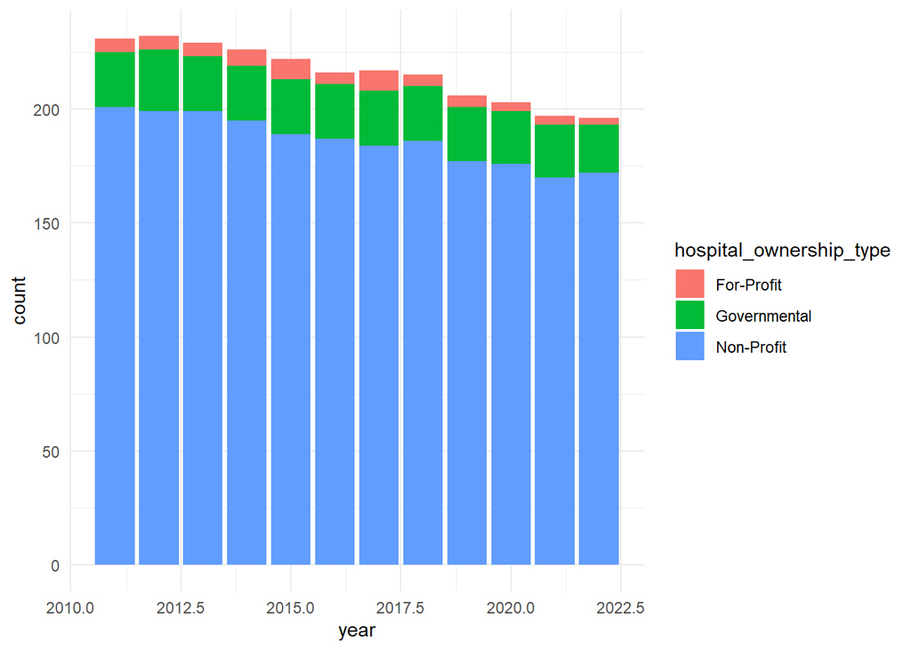

```r
Fully_combined %>%
  ggplot(mapping = aes(x = year,
                       group = hospital_ownership_type,
                       fill = hospital_ownership_type)) +
  geom_bar() +
  theme_minimal()
```